# World's Gross Domestic Product (GDP) Exploration

### by Hassanat Awodipe

## Content

1. Introduction
2. Preliminary Wrangling  
   2.1. Assessing  
   2.2. Structure of the dataset
3. Univariate Exploration  
   3.1. Conclusion
4. Bivariate Exploration  
   4.1. Conclusion
5. Multivariate Exploration  
   5.1. Conclusion
6. Conclusion and Limitations

## Introduction

> Gross Domestic Product (GDP) is the total income gaccrued from goods and services produced in a country for a given period of time. The aim of the analysis is to understand the effect of population on GDP and by extension, Income Class. The other factors that GDP such as imports, exports, etc will also be taken into consideration.

> The dataset was gotten from [kaggle](https://www.kaggle.com/datasets/truecue/worldsustainabilitydataset?select=WorldSustainabilityDataset.csv) and it was compiled from World bank. It contained two tables: **World Sustainability dataset** which contained the economic data of countries in the world from 2000 t0 2018 and the **Data dictionary** which described the features in the table.

## Preliminary Wrangling

```python
# import all packages and set plots to be embedded inline
import numpy as np
import pandas as pd
import matplotlib.pyplot as plt
import seaborn as sb
%matplotlib inline

# suppress warnings from final output
import warnings
warnings.filterwarnings('ignore')
```

```python
# read the dataset
economy = pd.read_excel('WorldSustainabilityDataset-Economy.xlsx')
economy.head()
```

|  | Country Name | Country Code | Year | Exports | Gross national expenditure | GDP | Gross savings | Inflation | Imports | Total natural resources rents | Income Class | Population | Rural population | Urban population | Regions |
| --- | --- | --- | --- | --- | --- | --- | --- | --- | --- | --- | --- | --- | --- | --- | --- |
| 0 | Aruba | ABW | 2001 | 70.497527 | 98.050626 | 1.920112e+09 | 19.327902 | 2.883604 | 68.548152 | 0.000712 | High income | 92892 | 53.661 | 46.339 | Latin America and Caribbean |
| 1 | Aruba | ABW | 2002 | 64.920863 | 104.460432 | 1.941341e+09 | 12.016691 | 3.315247 | 69.381295 | 0.000657 | High income | 94992 | 54.028 | 45.972 | Latin America and Caribbean |
| 2 | Aruba | ABW | 2003 | 63.101161 | 107.766722 | 2.021229e+09 | 14.461857 | 3.656365 | 70.867883 | 0.000700 | High income | 97016 | 54.394 | 45.606 | Latin America and Caribbean |
| 3 | Aruba | ABW | 2004 | 65.078967 | 103.484583 | 2.228492e+09 | 17.096515 | 2.529129 | 68.563550 | 0.000685 | High income | 98744 | 54.760 | 45.240 | Latin America and Caribbean |
| 4 | Aruba | ABW | 2005 | 68.552253 | 109.395973 | 2.330726e+09 | -2.041702 | 3.397787 | 77.948226 | 0.000653 | High income | 100028 | 55.125 | 44.875 | Latin America and Caribbean |

- `Country Name`and `Country Code` are the names and codes of the coutnries
- `Year` is the year the data was recorded
- `Exports` expressed as a % of GDP, represents the value of all goods and other market services provided to the rest of the world
- `Gross national expenditure` expressed as a % of GDP, sum of household final consumption expenditure, general government final consumption expenditure, and gross capital formation
- `GDP` value (in USD) of total goods and services produced within a country.
- `Gross savings` expressed as a % of GDP, gross national income less total consumption, plus net transfers
- `Inflation` annual change in % at which prices of goods and services brought by conusmers rise or fall. Estimated by using consumer price indices
- `Imports` expressed as a % of GDP, value of all goods and other market services received from the rest of the world
- `Total natural resources rents` % Income accrued from natural resources (e.g. Exports) as a percentage of GDP
- `Income Class` defines the economy of the country as defined by World bank
- `Population` the number of people in the country at that time
- `Rural population` the perecentage of people living in the rural areas
- `Urban population` the perecentage of people living in the urban areas
- `Regions` the countries Region as classified by UN.

### Assessing

```python
economy['Country Name'].nunique()
```

```
172
```

```python
# summary of data columns and rows
economy.info()
```

```
<class 'pandas.core.frame.DataFrame'>
RangeIndex: 3073 entries, 0 to 3072
Data columns (total 15 columns):
 #   Column                         Non-Null Count  Dtype
---  ------                         --------------  -----
 0   Country Name                   3073 non-null   object
 1   Country Code                   3073 non-null   object
 2   Year                           3073 non-null   int64
 3   Exports                        2954 non-null   float64
 4   Gross national expenditure     2889 non-null   float64
 5   GDP                            3073 non-null   float64
 6   Gross savings                  2648 non-null   float64
 7   Inflation                      2923 non-null   float64
 8   Imports                        2954 non-null   float64
 9   Total natural resources rents  3053 non-null   float64
 10  Income Class                   3073 non-null   object
 11  Population                     3073 non-null   int64
 12  Rural population               3073 non-null   float64
 13  Urban population               3073 non-null   float64
 14  Regions                        3073 non-null   object
dtypes: float64(9), int64(2), object(4)
memory usage: 360.2+ KB
```

```python
# number of null values in each column
economy.isnull().sum()
```

```
Country Name                       0
Country Code                       0
Year                               0
Exports                          119
Gross national expenditure       184
GDP                                0
Gross savings                    425
Inflation                        150
Imports                          119
Total natural resources rents     20
Income Class                       0
Population                         0
Rural population                   0
Urban population                   0
Regions                            0
dtype: int64
```

> I will now access each of the columns with missing rows indidvidually. I will not be dropping any row since they all represent valid countries and insights can be gathered from them. These rows make up 13.83% percent of the data so their effect should be insignificant. The most important columns (GDP, Population and Income Class) contain no null data. Also, I will continue my analysis with the Year column as an integer instead of converting to datetime because I won't be performing any mathematical calculation on it.

```python
# countries with null exports
null_exports = economy[economy['Exports'].isnull()]
print(null_exports['Regions'].unique())
print(null_exports['Year'].unique())
```

```
['Sub-Saharan Africa' 'Latin America and Caribbean'
 'Eastern and South-Eastern Asia' 'Central and Southern Asia']
[2001 2002 2003 2004 2005 2006 2007 2008 2009 2010 2011 2012 2013 2014
 2015 2016 2017 2018]
```

> The export data for the above countries were not recorded. These countries are from different regions so it is hard to conclude that the countries were not involved in any form of exportation which is why their Export cells are empty.

```python
# check the coutries with  null Gross national expenditure
null_GNE = economy[economy['Gross national expenditure'].isnull()]
print(null_GNE['Regions'].unique())
print(null_GNE['Year'].unique())
```

```
['Europe and Northern America' 'Sub-Saharan Africa'
 'Latin America and Caribbean' 'Eastern and South-Eastern Asia'
 'Central and Southern Asia' 'Oceania']
[2001 2002 2003 2004 2005 2006 2007 2008 2009 2010 2011 2012 2013 2014
 2015 2016 2017 2018]
```

```python
null_savings = economy[economy['Gross savings'].isnull()]
print(null_savings['Regions'].unique())
print(null_savings['Year'].unique())
```

```
['Northern Africa and Western Asia' 'Europe and Northern America'
 'Sub-Saharan Africa' 'Latin America and Caribbean'
 'Central and Southern Asia' 'Eastern and South-Eastern Asia' 'Oceania']
[2001 2002 2003 2004 2005 2006 2007 2008 2009 2010 2011 2012 2013 2014
 2015 2016 2017 2018]
```

> I expect that there won't be countries with null `Gross savings` since they all have `GDP` values. Could it be that these countries did not get to save for that period?

```python
null_inflation = economy[economy['Inflation'].isnull()]
print(null_inflation['Regions'].unique())
print(null_inflation['Year'].unique())
```

```
['Northern Africa and Western Asia' 'Latin America and Caribbean'
 'Europe and Northern America' 'Sub-Saharan Africa'
 'Central and Southern Asia' 'Eastern and South-Eastern Asia' 'Oceania']
[2001 2002 2003 2004 2005 2006 2007 2008 2009 2010 2011 2012 2013 2014
 2015 2016 2017 2018]
```

> Where the inflation is null, it is possible that the worth and quantity of the country's currency may have remained unchanged or that the data is simply missing.

```python
# countries with null imports
null_imports = economy[economy['Imports'].isnull()]
print(null_imports['Regions'].unique())
print(null_inflation['Year'].unique())
```

```
['Sub-Saharan Africa' 'Latin America and Caribbean'
 'Eastern and South-Eastern Asia' 'Central and Southern Asia']
[2001 2002 2003 2004 2005 2006 2007 2008 2009 2010 2011 2012 2013 2014
 2015 2016 2017 2018]
```

Similarly to the exports, these four continents have countries within then with their import data missing.

```python
null_natural_resources = economy[economy['Total natural resources rents'].isnull()]
print(null_natural_resources['Regions'].unique())
print(null_inflation['Year'].unique())
```

```
['Latin America and Caribbean' 'Sub-Saharan Africa'
 'Northern Africa and Western Asia' 'Eastern and South-Eastern Asia']
[2001 2002 2003 2004 2005 2006 2007 2008 2009 2010 2011 2012 2013 2014
 2015 2016 2017 2018]
```

> These continents also have countries within them with their total natural resources rents data missing.

After assessing all the null values in each column, I would like to understand the descriptive statistics

```python
# summary descriptive statistics
economy.describe()
```

|  | Year | Exports | Gross national expenditure | GDP | Gross savings | Inflation | Imports | Total natural resources rents | Population | Rural population | Urban population |
| --- | --- | --- | --- | --- | --- | --- | --- | --- | --- | --- | --- |
| count | 3073.000000 | 2954.000000 | 2889.000000 | 3.073000e+03 | 2648.000000 | 2923.000000 | 2954.000000 | 3053.000000 | 3.073000e+03 | 3073.000000 | 3073.000000 |
| mean | 2009.468597 | 42.286469 | 104.566075 | 3.598009e+11 | 22.779667 | 5.366414 | 47.168952 | 7.015880 | 3.908210e+07 | 42.782066 | 57.217934 |
| std | 5.184525 | 29.921096 | 18.616030 | 1.429281e+12 | 17.743002 | 9.926887 | 27.813000 | 10.730922 | 1.421234e+08 | 22.779309 | 22.779309 |
| min | 2001.000000 | 0.099465 | 40.110847 | 1.811170e+08 | -70.263214 | -18.108630 | 0.064705 | 0.000000 | 6.967100e+04 | 0.000000 | 8.461000 |
| 25% | 2005.000000 | 24.153863 | 96.530918 | 7.034111e+09 | 15.280295 | 1.620828 | 29.176293 | 0.385851 | 2.314901e+06 | 24.432000 | 39.248000 |
| 50% | 2009.000000 | 35.624428 | 102.842626 | 2.622423e+10 | 21.155895 | 3.461526 | 40.554196 | 2.122046 | 8.171950e+06 | 42.617000 | 57.383000 |
| 75% | 2014.000000 | 52.385802 | 112.449599 | 1.843880e+11 | 28.112501 | 6.797055 | 59.034408 | 8.878282 | 2.628619e+07 | 60.752000 | 75.568000 |
| max | 2018.000000 | 228.993771 | 264.782066 | 2.061190e+13 | 372.988127 | 359.936614 | 236.390969 | 81.949962 | 1.392730e+09 | 91.539000 | 100.000000 |

> Examining the columns which have negative values for `Gross savings` and `Inflation`.

```python
# gross savings below 0
economy[economy['Gross savings'] <= 0]['Income Class'].unique()
```

```
array(['High income', 'Low income', 'Upper-middle income',
       'Lower-middle income'], dtype=object)
```

```python
# inflation below 0
economy[economy['Inflation'] <= 0]['Income Class'].unique()
```

```
array(['High income', 'Upper-middle income', 'Lower-middle income',
       'Low income'], dtype=object)
```

> `Negative Gross savings` and `Negative inflation or deflation` seemed to have been recorded in a number of countries regardless of the `Income Class`. Negative gross savings is when the country saves less than it normally would and deflation is when there is a decrease in the prices of goods and services, excees supply or increase in buying power of consumers.

As a final wrangling step, I will change the `Income Class` to an ordered category data type.

```python
# create an order
income_class = ['High income', 'Upper-middle income', 'Lower-middle income', 'Low income']
income_order = pd.api.types.CategoricalDtype(ordered=True, categories=income_class)
economy['Income Class'] = economy['Income Class'].astype(income_order)
```

```python
# nominal categorical variable
economy['Regions'].unique()
```

```
array(['Latin America and Caribbean', 'Sub-Saharan Africa',
       'Europe and Northern America', 'Northern Africa and Western Asia',
       'Oceania', 'Central and Southern Asia',
       'Eastern and South-Eastern Asia'], dtype=object)
```

```python
economy['Year'].min(), economy['Year'].max()
```

```
(2001, 2018)
```

### Structure of the dataset

> Most of the variables are numeric except the `country name and code, income class and region`. The numeric variables are expressed as a percentage of the GDP except otherwise stated. Income class and Regions are the only categorical variables in the dataset with Income Class being ordinal. There is also the Year column.

> There are 7 region types: `Latin America and Caribbean, Sub-Saharan Africa, Europe and Northern America, Northern Africa and Western Asia, Oceania, Central and Southern Asia, Eastern and South-Eastern Asia`. And four income classes: `High income > Upper-middle income > Lower-middle income > Low income`

### Main feature(s) of interest in the dataset

> The main features in the dataset are the Population, GDP and Income class. I am interested in looking at the world's GDP as a whole. I want to understand how Population affects GDP and how GDP varies with Income Class. The more the people, the more the goods and services produced in the country and the more the GDP. Especially if they are located in the Urban region of the country. This then determines the Income Class

### Features that support the investigation of the feature(s) of interest

> Exports, Imports, Total natural resources rents, and Gross savings and National expendtiure will also have some effect on the amount of GDP and may not make the GDP-Population-Income Class relationship a linear one.

## Univariate Exploration

### What is the distribution of GDP?

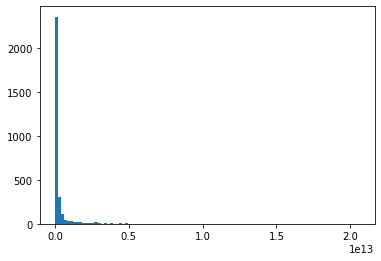

```python
# distribution of GDP
bins = 100
plt.hist(economy['GDP'], bins=bins);
```

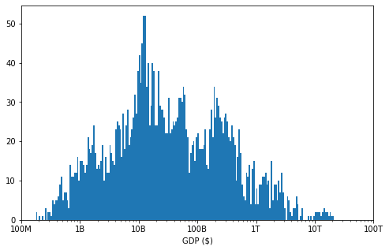

```python
# adjust the scale to a log scale
plt.figure(figsize=[8, 5])

log_binsize = 0.025
bins = 10 ** np.arange(0.9, np.log10(economy['GDP'].max())+log_binsize, log_binsize)

plt.hist(economy['GDP'], bins=bins)
plt.xscale('log')
plt.xlim(10**8, 10**14)
plt.xticks([10**8, 10**9, 10**10, 10**11, 10**12, 10**13, 10**14], ['100M', '1B', '10B', '100B', '1T', '10T', '100T'])
plt.xlabel('GDP ($)')

plt.show()
```

GDP has a long tail with a lot of smaller values and just a few values on the high side. When plotted on a log scale, the distribution appears to be normal with the highest count of GDPs in 10B range. There also appears to be more values after the 10B range.

Exports is one of the contributing factors to GDP. I would like to check the distribution of export

### What is the distribution of Exports?

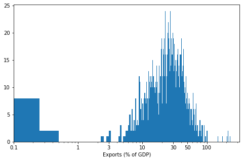

```python
# distribution of exports
plt.figure(figsize=[8, 5])

bins= np.arange(0, economy['Exports'].max()+0.25, 0.25)
plt.hist(economy['Exports'],  bins=bins);
plt.xscale('log')
ticks = [0.1, 1, 3, 10, 30, 50, 100]
labels = ['{}'.format(v) for v in ticks]
plt.xticks(ticks, labels)

plt.xlabel('Exports (% of GDP)')

plt.show()
```

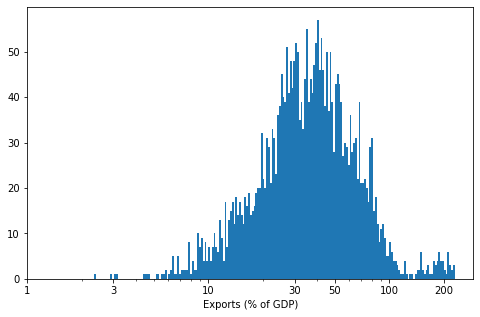

```python
# there is a distribution of a smaller percentage of export less than 1%
# I will closely examine those above 2%
plt.figure(figsize=[8, 5])

log_binsize = 0.010
bins = 10 ** np.arange(0.3, np.log10(economy['Exports'].max())+log_binsize, log_binsize)

plt.hist(economy['Exports'], bins=bins)
plt.xscale('log')
ticks = [1, 3, 10, 30, 50, 100, 200]
labels = ['{}'.format(v) for v in ticks]
plt.xticks(ticks, labels)

plt.xlabel('Exports (% of GDP)')

plt.show()
```

The distribution of Exports seems to fall into two groups: values less than 5% and values above, although the former seems more like outliers. The Export values when plotted on a log scale are normally distributed with a lot of values between 40 and 50%.

Next, I will look at Total natural resources rents which shows the income accured from natural resources produced in the country. Like Exports, this tend to increase the GDP.

### What is the distribution of the Total Natural Resources?

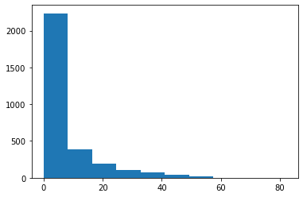

```python
# similarly to the GDP distribution, this also has a long tail
plt.hist(economy['Total natural resources rents']);
```

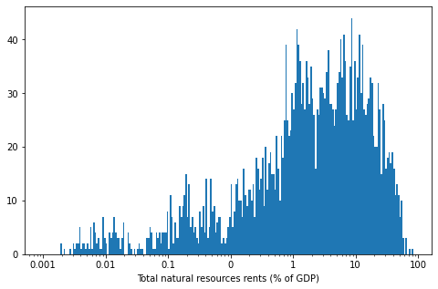

```python
# adjust to a log scale
log_binsize = 0.025
bins = 10 ** np.arange(-4, (np.log10(economy['Total natural resources rents'].max())+log_binsize), log_binsize)

plt.figure(figsize=[8, 5])

plt.hist(economy['Total natural resources rents'], bins=bins);
plt.xscale('log')
plt.xticks([10**-4, 10**-3, 10**-2, 10**-1, 10**0, 10**1, 10**2], [0.001, 0.01, 0.1, 0, 1, 10, 100])
plt.xlabel('Total natural resources rents (% of GDP)')

plt.show()
```

When converted to a log scale, the distribution of Total natural resources becomes left skewed and somewhat bimodal. A higher proportion falls below the 10% range of GDP. But it seems like a lot of countries do not gain so much from Total natural resources.

Import is another factor that affects the GDP of a country. If a country exports more than it imports, it would have a high GDP but if it imports more than it exports, it would have a low GDP according to the [Export-led growth Theory](https://smartech.gatech.edu/bitstream/handle/1853/51636/final.pdf)

### What is the distribution of the Imports?

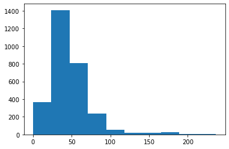

```python
# it has a fairly long tail
plt.hist(economy['Imports']);
```

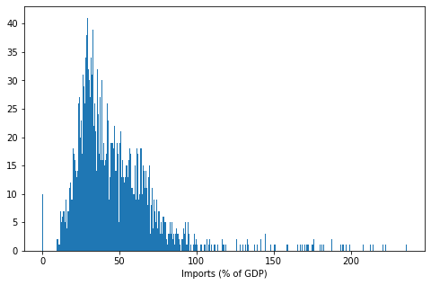

```python
plt.figure(figsize=(8,5))

bins = 600
plt.hist(economy['Imports'], bins=bins);
plt.xlabel('Imports (% of GDP)');
```

A higher proportion of the distribution of imports is less than 50%. Contrary to the exports distribution, the outliers are on the right indicating that fewer countries spend more on Imports. But these few countries really spend a lot, as much as 200% of their GDP.

### What is the distribution of Gross National Expenditure?

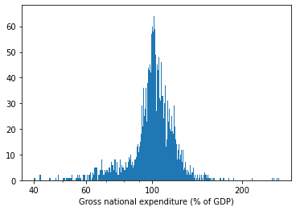

```python
# these features.
bins = 500
economy['Gross national expenditure'].hist(bins = 500)
plt.xscale('log')
plt.xticks([4*10**1, 6*10**1, 10**2, 2*10**2], [40, 60, 100, 200])
plt.grid(False)
plt.xlabel('Gross national expenditure (% of GDP)')

plt.show()
```

The distribution of gross national expenditure is narrowly normal. A high proportion of national expenditure is 100% GDP indicating that final consumpion, household expenditure and government general expenditure is as high as GDP. Gross national expendtiure is usually seen as a positive contributor to GDP.

### What is the distribution of Gross Savings?

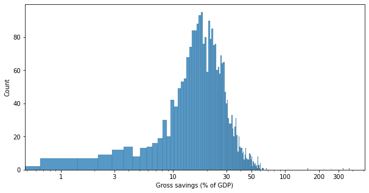

```python
plt.figure(figsize=(10,5))

sb.histplot(economy['Gross savings'], bins=600);
plt.xscale('log')

ticks = [1, 3, 10, 30, 50, 100, 200, 300]
labels = ['{}'.format(v) for v in ticks]
plt.xticks(ticks, labels)

plt.xlabel('Gross savings (% of GDP)');
```

A lot of values for gross savings are around 20% of the corresponding GDP. The histogram does not seem to capture the negative gross savings values. Gross savings is generally less than expenditure.

### What is the distribution of Inflation?

```python
economy['Inflation'].min(), economy['Inflation'].max()
```

```
(-18.10863013, 359.9366143)
```

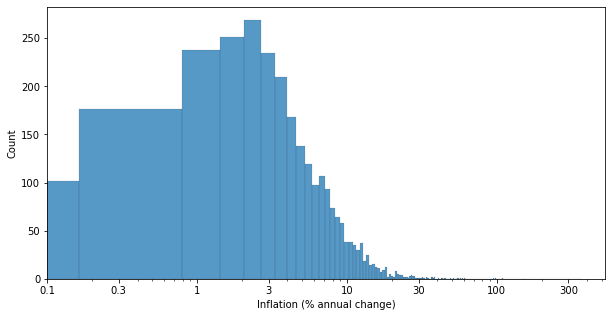

```python
plt.figure(figsize=(10,5))

sb.histplot(economy['Inflation'], bins=600)
plt.xscale('log')
ticks = [0.1, 0.3, 1, 3, 10, 30, 100, 300]
labels = ['{}'.format(v) for v in ticks]
plt.xticks(ticks, labels)

plt.xlabel('Inflation (% annual change)');
```

Inflations values are commonly low with a few high outliers from 30%. The most common values for is around 2%. Again, the histogram does not seem to capture the negative gross savings values.

### What is the distribution of population?

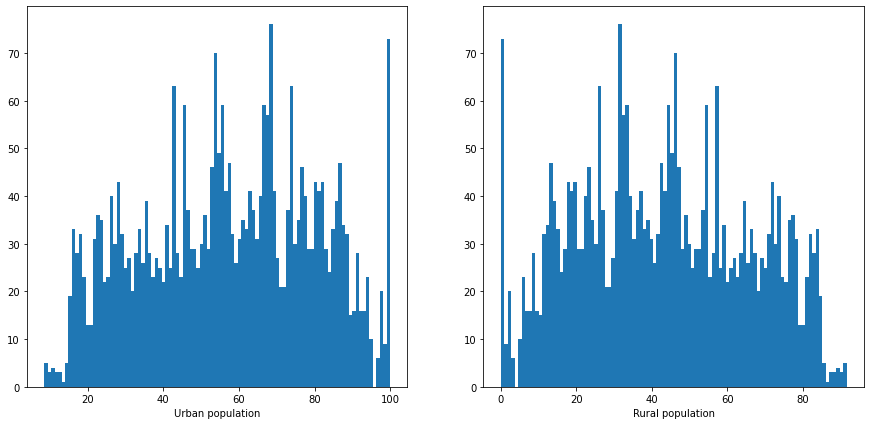

```python
# use urban and rural population
plt. figure(figsize=(15, 7))

plt.subplot(1, 2, 1)
plt.hist(economy['Urban population'], bins=100);
plt.xlabel('Urban population');

plt.subplot(1, 2, 2)
plt.hist(economy['Rural population'], bins=100);
plt.xlabel('Rural population');
```

The urban and rural population distributions have an inverted relationship. This is because they are expressed as a precentage of the overall population and add up to 100. It appears that there are a lot of countries with no rural population and most countires have a ratio of 65:35 for their urban-rural ratio.

Finally, I will plot countplots to check the distribution of the two categorical variables.

### What is the distribution of Income Class?

```python
# choose a uniform color for the bars
base_color = sb.color_palette()[0]
```

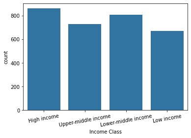

```python
# distribution of income class
sb.countplot(data=economy, x='Income Class', color=base_color);
plt.xticks(rotation=10)

plt.show()
```

Next, I would like to examine the distribution of countries across the Regions.

### What is the distribution of Regions?

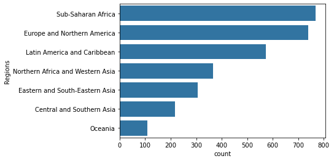

```python
# distribution of regions
sb.countplot(data=economy, y='Regions', color=base_color, order=economy['Regions'].value_counts().index);
```

Sub-Saharan Africa is the region with the highest count of observations in the dataset while Oceania has the lowest number of observations.

### Conclusion

### Discuss the distribution(s) of your variable(s) of interest. Were there any unusual points? Did you need to perform any transformations?

> GDP, Population and Income Class are the variables of interets. There are more high income and upper middle income observations than there are low income and lower middle income observations in the dataset (assuming the countries are **not** uniquely counted). The GDP had a wide range of values so I used a log transformation. This resulted in a normal distribution with higher proportion of values around the 10B range. There is a high ratio of 65:35 for urban-rural population.

### Of the features you investigated, were there any unusual distributions? Did you perform any operations on the data to tidy, adjust, or change the form of the data? If so, why did you do this?

> Most of the variables required a log transformation as they had long tails either to the left or right of the axis. It was interesting to see that the world spends more on imports than it gains from exports. And that there is little income gotten from natural resources. Also, there was a record of 300% inflation rate.

## Bivariate Exploration

### What is the relation among GDP and the other numeric variables?

```python
# split the numeric variables into two groups: those that add to the GDP and those that do not add to the GDP.
add_GDP = ['GDP', 'Exports', 'Gross national expenditure', 'Total natural resources rents', 'Population']

minus_GDP = ['GDP', 'Imports', 'Gross savings', 'Inflation']
```

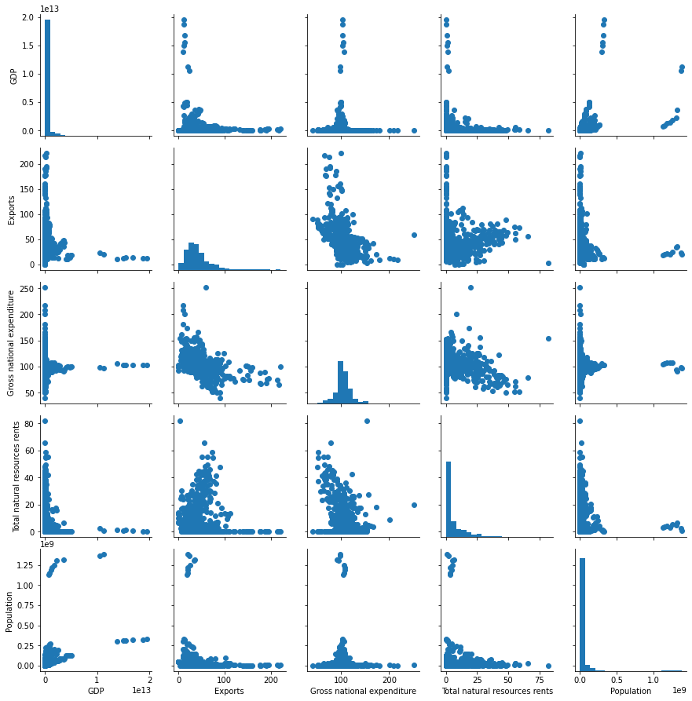

```python
# variables that add to the GDP
# using a random sample of the data
samples = np.random.choice(economy.shape[0], 1000, replace = False)
economy_samp = economy.loc[samples,:]

g = sb.PairGrid(data = economy_samp, vars = add_GDP)
g = g.map_diag(plt.hist, bins = 20);
g.map_offdiag(plt.scatter);
```

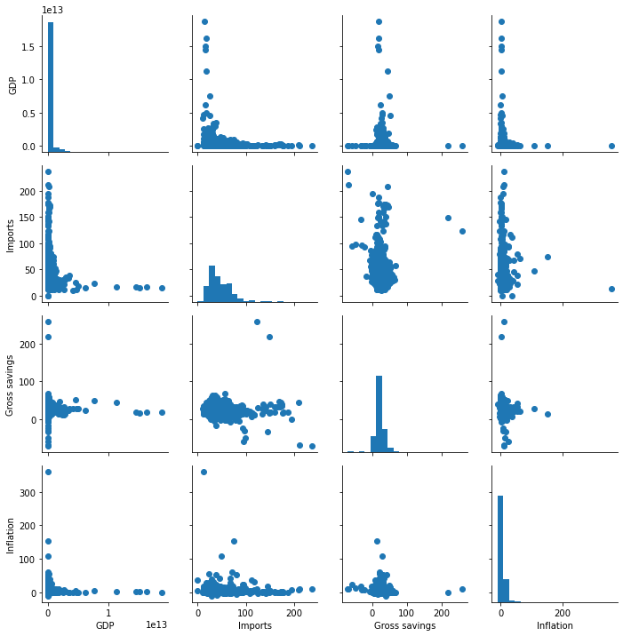

```python
# variables that add to the GDP
samples = np.random.choice(economy.shape[0], 1000, replace = False)
economy_samp = economy.loc[samples,:]

g = sb.PairGrid(data = economy_samp, vars = minus_GDP)
g = g.map_diag(plt.hist, bins = 20);
g.map_offdiag(plt.scatter);
```

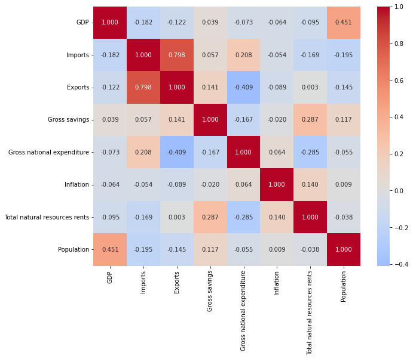

```python
# consider the all the numeric features in the dataset and how they compare to GDP
all_vars = ['GDP', 'Imports', 'Exports', 'Gross savings', 'Gross national expenditure', 'Inflation',
                'Total natural resources rents', 'Population']

plt.figure(figsize = [10, 8])

sb.heatmap(economy[all_vars].corr(), annot = True, fmt = '.3f', center = 0, cmap='coolwarm')

plt.show()
```

The first pair grid shows that there is a linear correlation between GDP and Population. The relation of GDP with exports, gross national expenditure or natural resources is not exactly clear.

There seems to be a negative relation between exports and natural expenditure.

It was hard to understand the plots in the second plot grid so I examined them using a heatmap.It was surprising to see that GDP had a negative correlation with a number of variables including Exports. Exports and Imports have a positive correlation as well as population and GDP albeit not as strong.

Next, I will check the performace of the GDP over the years as well as population growth.

### How has population growth affected GDP?

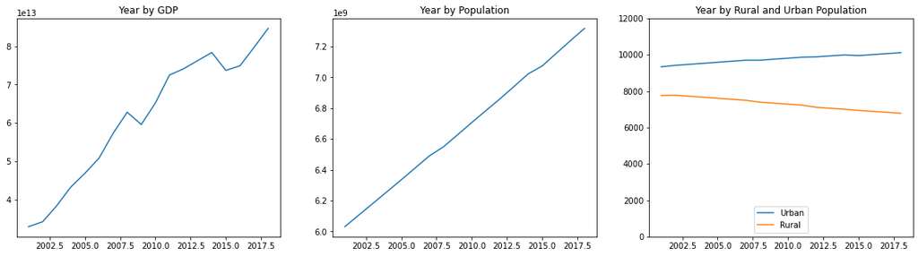

```python
plt.figure(figsize=(20, 5))

plt.subplot(1, 3, 1)
plt.plot(economy.groupby(['Year'])['GDP'].sum());
plt.title('Year by GDP');

plt.subplot(1, 3, 2)
plt.plot(economy.groupby(['Year'])['Population'].sum());
plt.title('Year by Population');

plt.subplot(1, 3, 3)
plt.plot(economy.groupby(['Year'])['Urban population'].sum(), label='Urban');
plt.plot(economy.groupby(['Year'])['Rural population'].sum(), label='Rural');
plt.ylim(0, 12000)
plt.title('Year by Rural and Urban Population');
plt.legend(loc='lower center');
```

Since 2001, there has been a steady rise in GDP. A slight drop occurred between mid-2007 and 2009. Then another drop in 2015.

By examining based on Rural and Urban Population, we can see that the increase in urban population is related to that of GDP and unaffected by the decline of Rural Population. Also interesting to see that the migration from Rural areas to Urban areas continues to grow.

I will now closely examine the rise and fall of GDP from 2010.

### How has GDP improved from 2010 to 2018

```python
# pivot the years from 2010 into individual columns
gdp_year = economy[['Country Name', 'GDP', 'Year']]
gdp_year = gdp_year.query('Year >= 2010' )
gdp_year.pivot(index='Country Name', columns='Year', values='GDP')
```

| Year Country Name | 2010 | 2011 | 2012 | 2013 | 2014 | 2015 | 2016 | 2017 | 2018 |
| --- | --- | --- | --- | --- | --- | --- | --- | --- | --- |
| Albania | 1.192693e+10 | 1.289077e+10 | 1.231983e+10 | 1.277622e+10 | 1.322814e+10 | 1.138685e+10 | 1.186120e+10 | 1.301969e+10 | 1.514702e+10 |
| Algeria | 1.612070e+11 | 2.000130e+11 | 2.090590e+11 | 2.097550e+11 | 2.138100e+11 | 1.659790e+11 | 1.600340e+11 | 1.700970e+11 | 1.754150e+11 |
| Angola | 8.379950e+10 | 1.117900e+11 | 1.280530e+11 | 1.367100e+11 | 1.457120e+11 | 1.161940e+11 | 1.011240e+11 | 1.221240e+11 | 1.013530e+11 |
| Antigua and Barbuda | 1.148700e+09 | 1.137637e+09 | 1.199948e+09 | 1.181448e+09 | 1.249733e+09 | 1.336693e+09 | 1.436585e+09 | 1.467978e+09 | 1.605352e+09 |
| Argentina | 4.236270e+11 | 5.301630e+11 | 5.459820e+11 | 5.520250e+11 | 5.263200e+11 | 5.947490e+11 | 5.575310e+11 | 6.436290e+11 | 5.176270e+11 |
| ... | ... | ... | ... | ... | ... | ... | ... | ... | ... |
| Venezuela, RB | 3.931920e+11 | 3.164820e+11 | 3.812860e+11 | 3.710050e+11 | 4.823590e+11 | NaN | NaN | NaN | NaN |
| Vietnam | 1.159320e+11 | 1.355390e+11 | 1.558200e+11 | 1.712220e+11 | 1.862050e+11 | 1.932410e+11 | 2.052760e+11 | 2.237800e+11 | 2.452140e+11 |
| West Bank and Gaza | 9.681500e+09 | 1.118610e+10 | 1.220840e+10 | 1.351550e+10 | 1.398970e+10 | 1.397240e+10 | 1.540540e+10 | 1.612800e+10 | 1.627660e+10 |
| Zambia | 2.026556e+10 | 2.345952e+10 | 2.550306e+10 | 2.803724e+10 | 2.714102e+10 | 2.125122e+10 | 2.095841e+10 | 2.587360e+10 | 2.631164e+10 |
| Zimbabwe | 1.204166e+10 | 1.410192e+10 | 1.711485e+10 | 1.909102e+10 | 1.949552e+10 | 1.996312e+10 | 2.054868e+10 | 1.901533e+10 | 1.952362e+10 |

171 rows × 9 columns

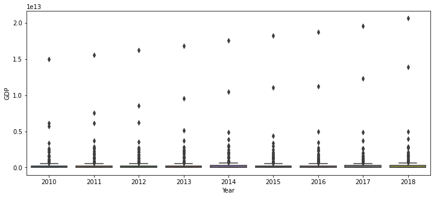

```python
# boxplot represenation of year by GDP
plt.figure(figsize=(12,5))
sb.boxplot(data=gdp_year, x='Year', y='GDP');
```

From the above, it is clear that maximum GDP outliers continues to grow indicating that just a few countries are experiencing rapid economic growth. I will change the above y axis to a log scale so that the plot can be seen clearly.

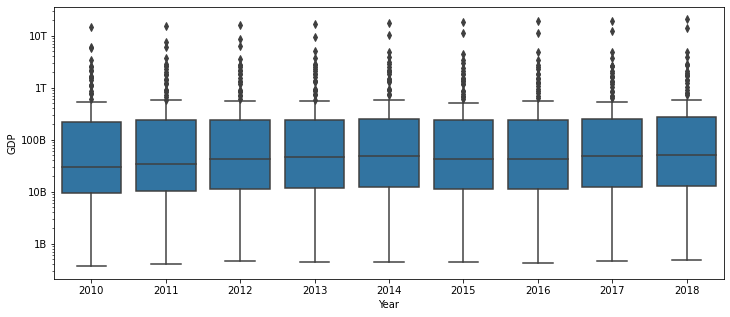

```python
# use a log scale for the GDP axis
plt.figure(figsize=(12,5))

sb.boxplot(data=gdp_year, x='Year', y='GDP', color=base_color);

plt.yscale('log')
plt.yticks([ 10**9, 10**10, 10**11, 10**12, 10**13], ['1B', '10B', '100B', '1T', '10T']);
```

### What is the distribution of Income Class and Regions based on GDP, Population?

```python
def violingrid(x, y, **kwargs):
    """ plots a violin plot using PairGrid. """
    sb.violinplot(x, y, color=base_color, inner=None)
    plt.xscale('log');
```

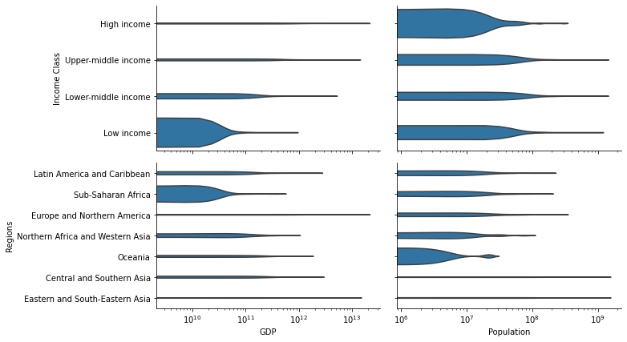

```python
# call the function
# the regions have different orders for GDP and Population so no order was plotted
categorical_vars = ['Income Class', 'Regions']
fig = sb.PairGrid(data=economy, x_vars = ['GDP', 'Population'], y_vars=categorical_vars,
                height = 3, aspect = 1.5)
fig.map(violingrid);
```

Comparing regions and GDP, there is a high distribution of countries in Sub-Saharan Africa with GDP less than 100B and they have the lowest maximum GDP. Europe and Northern America have the highest maximum GDP but a narrow distribution of countries. In summary, none of the violin plots appear to be normally distributed.

A better way to understand the GDP and how it is generated in the countries is to engineer the GDP Per capita feature. This is the average income gotten from each member of a country. We may then check the GDP Per capita for each income class or each region to understand why countries in the same region do not belong to the same income class.

### What is the average GDP Per capita for each Income Class?

```python
# derive the GDP Per Capita for each country and find the distribution.
economy['GDP Per Capita'] = economy['GDP'] / economy['Population']
```

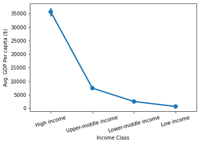

```python
# use pointplot to get the means
sb.pointplot(data=economy, x= 'Income Class', y='GDP Per Capita', color=base_color)
plt.xticks(rotation=15);
plt.ylabel('Avg. GDP Per capita ($)');
```

The average income of a person located in a high income economy is 35k while that of someone located in a low income economy is less than 5k. This indicates that the GDP of an economy is mostly determined by the income each citizen generates.

Finally, I would like to understand the distribution of income class by Regions.

### How many countries in each region belong to each income class?

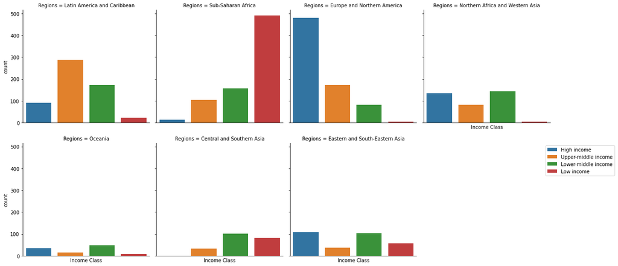

```python
# without taking into account individual countries
# facetgrid to examine the count of income class for each region
fig = sb.FacetGrid(data=economy, col='Regions', hue='Income Class', col_wrap=4, height=4)
fig.map(sb.countplot, 'Income Class')
plt.xticks(rotation=15)

plt.legend(loc='upper left', bbox_to_anchor=(2,1))
plt.xticks([])
plt.tight_layout()
plt.show()
```

```python
# the facetgrid is not clear enough so I will use a heat map
# group by region and income class to get the counts
region_income = economy.groupby(['Regions', 'Income Class']).size().reset_index(name='count')
region_income = region_income.pivot(index='Regions', columns='Income Class', values='count')
region_income
```

| Income Class Regions | High income | Upper-middle income | Lower-middle income | Low income |
| --- | --- | --- | --- | --- |
| Central and Southern Asia | 0 | 32 | 102 | 82 |
| Eastern and South-Eastern Asia | 108 | 37 | 103 | 57 |
| Europe and Northern America | 479 | 172 | 82 | 5 |
| Latin America and Caribbean | 91 | 287 | 172 | 22 |
| Northern Africa and Western Asia | 135 | 82 | 145 | 5 |
| Oceania | 36 | 16 | 48 | 8 |
| Sub-Saharan Africa | 13 | 105 | 157 | 492 |

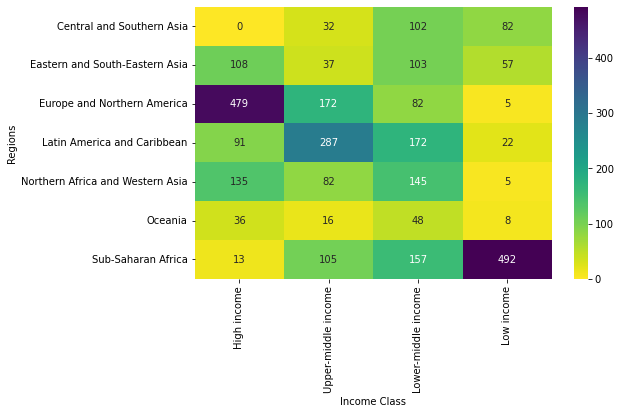

```python
# heatmap for income class by region
plt.figure(figsize=(8,5))
sb.heatmap(region_income, annot=True, fmt='d', cmap='viridis_r');
```

For the period that the data was collected, the count of high income observations is the highest and this makes the world seem like a genrally high income place.

However, because the data was collected over a period of time for the same countries and the income classes for these countries in the regions keep changing, the counts are not unique.

### Conclusion

### Relationships observed in this part of the investigation. How the feature(s) of interest vary with other features in the dataset

> It was strange to see the negative correlation between GDP and exports/natural resources. Infact GDP had negative correlation with the items that are supposed to contribute to the GDP. This is not far-fetched as there is a theory called the **paradox of plenty theory** which states that a country may focus on exporting just one produce which is not a value added-export while negelecting other sectors of its economy and then decrease its GDP.

### Interesting relationships between the other features

> There was a positive correlation between exports and imports. And it was odd to see no correlation between natural resources and exports. Does this mean that countries exported only finished goods? I also observed that population constantly increased with Year.

## Multivariate Exploration

### What effect did inflation have on GDP from 2010?

```python
# subset the data for the years from 2010
gdp_data = economy[(economy['Year'] >= 2010)]
```

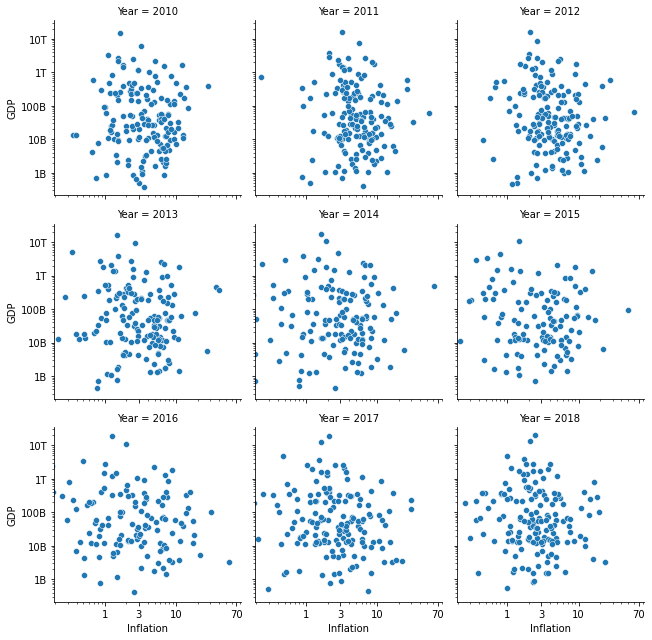

```python
# use facetgrid and scatterplot to find the relation between GDP and Population and use Year to create column groups
fig = sb.FacetGrid(data=gdp_data, col='Year', col_wrap=3, height=3, aspect=1)
fig.map(sb.scatterplot, 'Inflation', 'GDP')

plt.xscale('log')
plt.yscale('log')

ticks = [1, 3, 10, 70]
labels = ['{}'.format(v) for v in ticks]
plt.xticks(ticks, labels)

plt.yticks([10**9, 10**10, 10**11, 10**12, 10**13], ['1B', '10B', '100B', '1T', '10T']);
```

This relationship between GDP and Inflation appear constant throughout 2010 and 2018 however, in 2014, there was a higher occurence of deflation points which can be seen lying on the yaxis. This may have lead to the fall in GDP in 2015. Deflation causes a reduction in prices of goods and services. Overall, inflations values are mostly between 1 and 10.

### What effect did Population and GDP have on the other features from 2010?

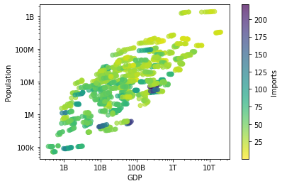

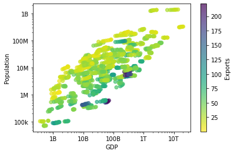

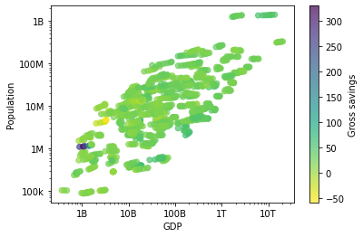

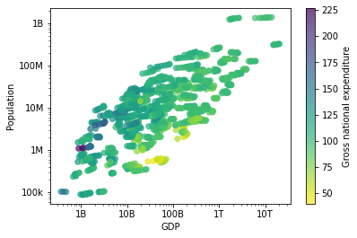

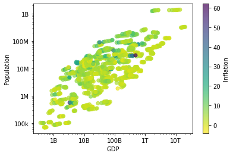

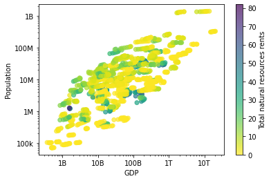

```python
# scatter plot to see how the other features vary with GDP and Population.
features=['Imports', 'Exports', 'Gross savings', 'Gross national expenditure', 'Inflation',
          'Total natural resources rents']
for feature in features:
    plt.scatter(data=gdp_data,  x='GDP', y='Population', c=feature, cmap='viridis_r', alpha=0.7)
    plt.xscale('log')
    plt.yscale('log')

    plt.colorbar(label=feature)
    plt.xlabel('GDP')
    plt.ylabel('Population')
    plt.xticks([10**9, 10**10, 10**11, 10**12, 10**13], ['1B', '10B', '100B', '1T', '10T'])
    plt.yticks([10**5, 10**6, 10**7, 10**8, 10**9], ['100k', '1M', '10M', '100M', '1B'])

    plt.show()
```

Where the GDP and Population are high, import tends to be low. The highest values of imports lie between the 100B and 1T GDP range and 1M and 10M Population range. For exports, there are more low points spread around. Highest export points can be seen around the 10B-500B GDP range suggesting that high GDP and high exports have things in common. The low export points are spread around high population and low GDP. Generally, there are more low export points than there are low import points.

The percentage of Gross national expendtiure appears to be generally high than that of Savings. Most of the highest expenditure points are concentrated around the areas of low GDP (less than 100B). Expenditure appears to increase with population but decrease with GDP

Inflation looks generally low and appears to be somewhat constant with a couple of outliers. Total natural resources is also generally low with few high outliers.